# Running Data Dashboard

April 4, 2019

## Project motivation

As a runner, it is useful to keep a log of past exercise and be able to efficiently explore that information in several ways.

Some useful metrics include

- total time spent running
- total running distance
- average running pace (speed)

It’s common to look at daily runs, or running volume aggregated over weeks and months, in order to monitor improvement and be mindful of training load increases when preventing injuries.

This application provides a convenient visual tool for this analysis.

## App Usage

This application has two views of server-provided running data which appear in separate tabs

- A plot of the user-selected metric at a user-selected aggregation level, possibly with added trendline(s)
- A table of time & distance data at the user’s chosen aggregation level

Controlling the app is simple

- Radio buttons for aggregation level (daily, weekly, or monthly)
- Radio buttons for metric (time, distance, pace)
- Checkbox selection of trend lines (linear or scaled exponential)

## Example Plot

### Weekly Running Time with Linear Trend

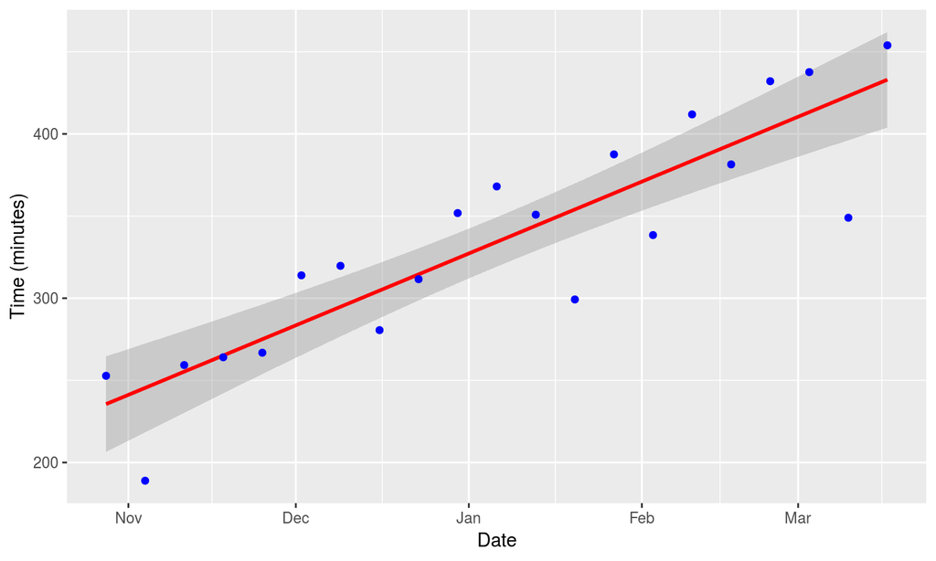

## Example Table

### Weekly Running

| Start Date | End Date | Time (minutes) | Distance (miles) |
| --- | --- | --- | --- |
| 2018-10-28 | 2018-11-03 | 252.78 | 33.09 |
| 2018-11-04 | 2018-11-10 | 188.92 | 25.33 |
| 2018-11-11 | 2018-11-17 | 259.31 | 34.12 |
| 2018-11-18 | 2018-11-24 | 264.06 | 34.65 |
| 2018-11-25 | 2018-12-01 | 266.83 | 35.33 |

Full Demo at [ShinyApps](https://tylerc.shinyapps.io/Coursera_DDP_Final/)